# Group 4 Final Project

## Introduction

For this project, we have analyzed a sample of 75,000 individual data points sourced from the City of Denver’s crime database, covering the preceding 5 calendar years. Each data point encompasses neighborhood attributes where the crime occurred, such as median income, demographics, and more, along with specifics of the crime itself, including its description and time. We aim to investigate whether there exists a positive correlation between the percentage of impoverished residents and their school attendance. Furthermore, we seek to determine if the occurrence of crimes is evenly distributed among the three crime categories: non-violent, violent, and property.

## Is there a positive association between the percent of a neighborhood in poverty and the percent of the population in school?

This question did not require data manipulation. We have 75,000 observations available for this question, however each observation is representative of the percent of its neighborhood’s population in school and in poverty so many of the entries in the data set are repeated.

Our hypotheses are:

$$H_0: \rho =0 \text{ (No association
between the percent in poverty and the percent of the population in
school).}$$
$$H_a: \rho > 0 \text{
(Positive association between the percent in poverty and the percent of
the population in school).}$$

We created a scatter plot to visualize these two variables. The majority of the cases had a poverty percentage of between 0% and 10% and a percentage of school between 12.5% and 25%. It appears that there is a positive association between the two variables.

To test the hypothesis we performed a correlation test for correlation. The resulting $R^2$ value was 0.02201, and the resulting p-value was 0. The percentage in poverty accounts for 2.201% of the variability in the percent of the population in school. There is sufficient evidence that there is a positive association between the percent of a neighborhood in poverty and the percent of the population in school.

## Are the different types of crime (non-violent, violent, and property) not equally likely to occur.

We have 75,000 observations available for this question.

Data manipulation: We began by categorizing the variable ‘crime_category’ into three groups from which we created a new variable called ‘categorized_crime.’ Data points that received the ‘violent’ type for ‘crime_category’ includes crimes such as assault, robbery, homicide, with data points receiving ‘property_crimes’ are theft, arson, etc. The rest are categorized a ‘non-violent.’ After performing those operations, we are left with being able to answer the following hypothesis:

$$H_0: \text{The distribution of crimes is
equal across the three crime categories (non-violent, violent, and
property).}$$
$$H_a: \text{The
distribution of crimes is not equal across the three crime categories
(non-violent, violent, and property).}$$

We created a bar chart representing the three types of crimes in our new ‘crime_categorized’ variable. Across all of the crime groups, we can easily notice that all of the crimes are not equal in proportion to each other.

## Figures

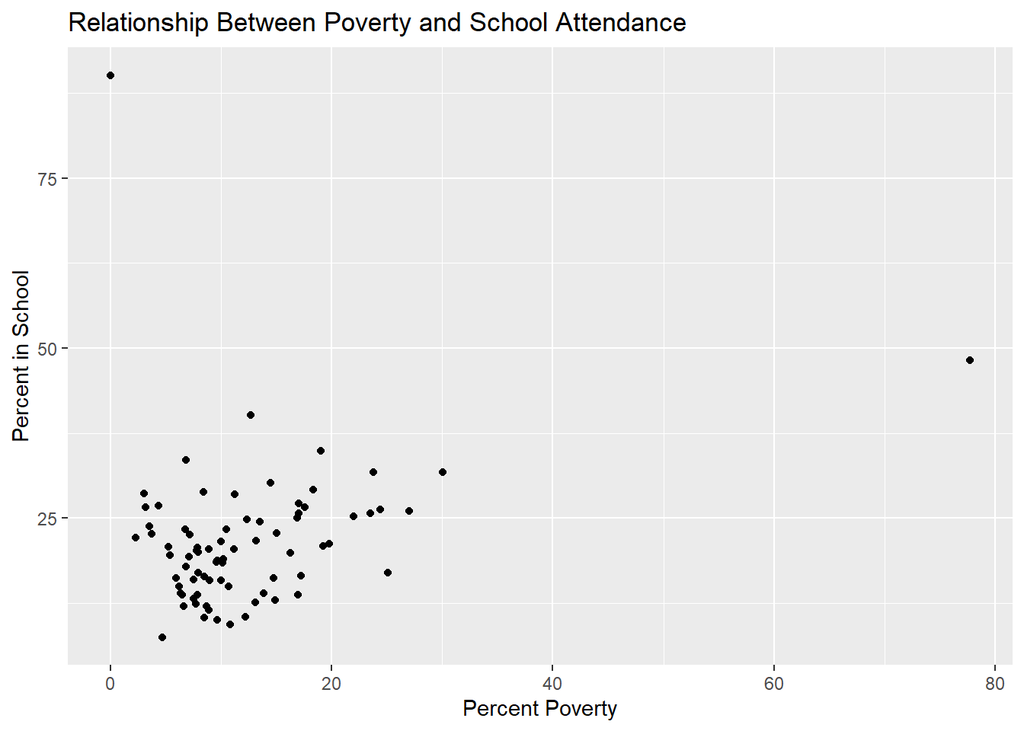

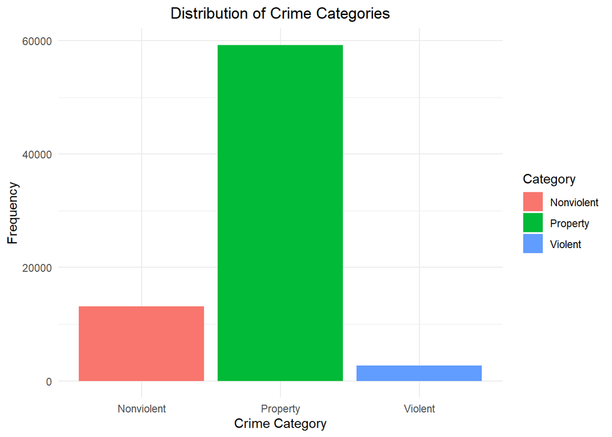

# Appendix

```r
cor.test(percent_in_school ~ percent_poverty, data=ResearchQuestion1)
```

```
##
##  Pearson's product-moment correlation
##
## data:  percent_in_school and percent_poverty
## t = 41.085, df = 74998, p-value < 2.2e-16
## alternative hypothesis: true correlation is not equal to 0
## 95 percent confidence interval:
##  0.1413573 0.1553559
## sample estimates:
##      cor
## 0.148364
```

```r
# calculate observed stats
observed <- table(ResearchQuestion2$crime_category)
# null proportion, all types of crime are equal
# could be swapred for national data to see if denver matches the national expected values
expected_prob <- c(1/3, 1/3, 1/3)

# chi squared inference
xchisq.test(x = observed, p = expected_prob)
```

```
##
##  Chi-squared test for given probabilities
##
## data:  x
## X-squared = 72479, df = 2, p-value < 2.2e-16
##
##  13118    59227     2655
## (25000.00) (25000.00) (25000.00)
## [ 5647.28] [46859.50] [19971.96]
## < -75.15> < 216.47> <-141.32>
##
## key:
##  observed
##  (expected)
##  [contribution to X-squared]
##  <Pearson residual>
```